# hw7

Ty Darnell

November 17, 2018

# Problem 1

$\alpha=.05$

$OR=\dfrac{\pi_1/(1-\pi_1)}{\pi_2/(1-\pi_2)}=3$

$\pi_2$reference proportion=1/50=.02

$\pi_1 =\dfrac{\pi_2OR}{1+\pi_2(OR-1)}=\dfrac{.02*3}{1+.02(3-1)}=0.05769231$

$p_{diff}=\pi_1-\pi_2=0.05769231-.02=0.03769231$

n=100+100=200

$H_0: \pi_1=\pi_2$

$H_A: \pi_1\neq \pi_2$

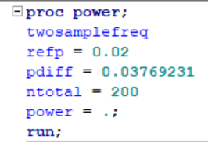

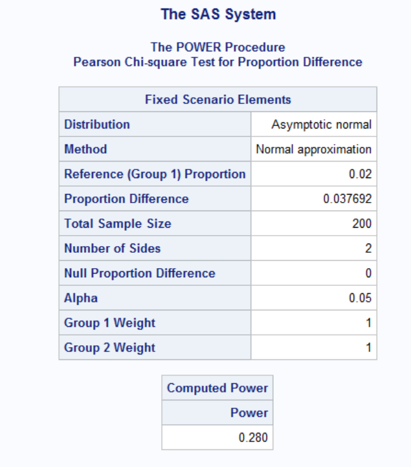

power = .28

The power to dectect OR=3 is .28

I would not reccomend conducting this study because when $H_0$ is false you only reject it 28% of the time.

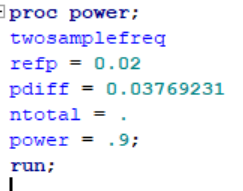

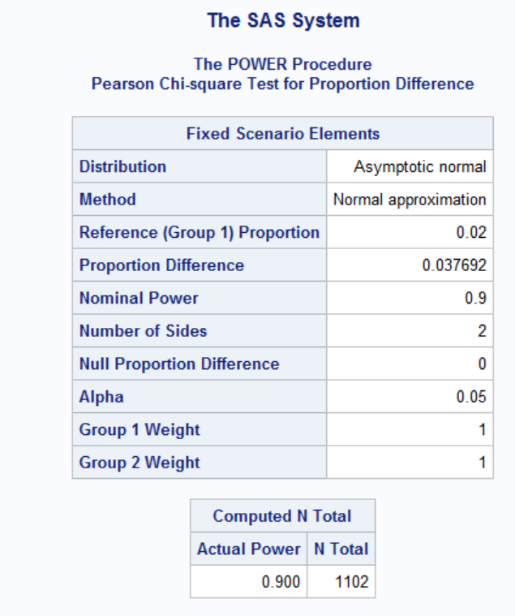

Using a power of .9 we get n=1102

Thus I would recommend 551 cases and 551 controls in conducting the study.

# Problem 2

## Part a)

$\mu=50$

$sd_x=8$

$sd_e=10$

$\beta=.2$

```r
set.seed(251)
mu <- 50
sdx <- 8
sdy <- 10
mysim <- function(n,nsims){
rejects <- 0
for (ii in 1:nsims){
x <- rnorm(n,mu,sdx)
mdiff <- .2*x
y <- rnorm(n,mdiff,sdy)
lmd <- lm(y~x)
if (summary(lmd)$coefficients[8]<0.05) rejects <- rejects + 1
}
print(paste("estimated power:",rejects/nsims))
}
simres=mysim(413,10000)
```

```
## [1] "estimated power: 0.9004"
```

Running 10,000 simulations it appears that a sample size of 413 is needed to detect $\beta=.2$ with power=.9

## Part b)

$s_x=8$

$s_e=10$

$Var(y)=Var(\alpha+\beta_1*X+\epsilon)$

$\beta_1^2Var(X)+Var(\epsilon)=.2^2*8^2+10^2=102.56$

$s_y=\sqrt{102.56}=10.12719$

$\rho=\hat{\beta_1}\dfrac{s_X}{s_Y}=.2(8/10.12719)=.158$

$H_0: \rho=0$

$H_A: \rho=.158$

$Z_0=(1/2)\log(\dfrac{1+0}{1-0})=0$

$Z_1=(1/2)\log(\dfrac{1+.158}{1-1.158})=.1593348$

$n=\dfrac{(z_1-\alpha/2+z_1-\beta)^2}{Z_{\rho_1}-Z_{\rho_0}}+3=\dfrac{(1.96+1.28)^2}{(.1593348-0)^2}+3=416.4936\approx 417$

From the sample size formula it appears that a sample size of 417 is needed to detect $\beta=.2$ with power=.9. This is similar to the sample size of 413 from the simulations.